```python
import numpy as np
import pandas as pd
import matplotlib.pyplot as plt
```

```python
import nltk
nltk.download('stopwords')
```

```
True
```

# WEEK - 2:

# Sentence Tokenization

Sentence tokenizer breaks text paragraph into sentences

```python
from nltk.tokenize import sent_tokenize
text="""Hello Mr. Smith, how are you doing today? The weather is great, and city is awesome.
The sky is pinkish-blue. The movie was exciting and frightening."""
tokenized_text=sent_tokenize(text)
print(tokenized_text)
```

```
['Hello Mr. Smith, how are you doing today?', 'The weather is great, and city is awesome.', 'The sky is pinkish-blue.', 'The movie was exciting and frightening.']
```

# Word Tokenization

Word tokenizer breaks text paragraph into words

```python
from nltk.tokenize import word_tokenize
tokenized_word=word_tokenize(text)
print(tokenized_word)
```

```
['Hello', 'Mr.', 'Smith', ',', 'how', 'are', 'you', 'doing', 'today', '?', 'The', 'weather', 'is', 'great', ',', 'and', 'city', 'is', 'awesome', '.', 'The', 'sky', 'is', 'pinkish-blue', '.', 'The', 'movie', 'was', 'exciting', 'and', 'frightening', '.']
```

# Frequency Distribution

```python
from nltk.probability import FreqDist
fdist = FreqDist(tokenized_word)
print(fdist)
```

```
<FreqDist with 24 samples and 32 outcomes>
```

```python
fdist.most_common(4)
```

```
[('The', 3), ('is', 3), ('.', 3), (',', 2)]
```

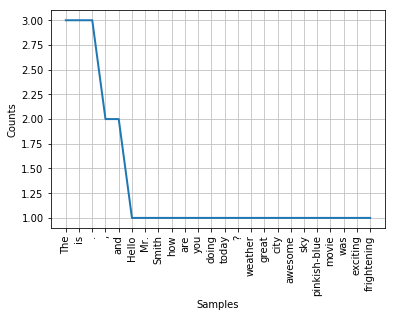

```python
# Frequency Distribution Plot
import matplotlib.pyplot as plt
fdist.plot(30,cumulative=False)
plt.show()
```

# Stopwords

Stopwords considered as noise in the text. Text may contain stop words such as is, am, are, this, a, an, the, etc.

In NLTK for removing stopwords, you need to create a list of stopwords and filter out your list of tokens from these words.

```python
from nltk.corpus import stopwords
stop_words=set(stopwords.words("english"))
print(stop_words)
```

```
{'a', 'here', 'her', "you'd", 'which', 'very', 'now', 'who', 'hers', 'mightn', 'through', 'isn', 'myself', 'she', 'these', 'and', 'don', 'been', "hasn't", 'against', 'more', 'over', 'o', 'while', 'but', 'needn', 'for', 'have', 'any', 'again', 't', 'mustn', 'can', 'why', 'theirs', 'this', "won't", 'm…
```

# Removing Stopwords

```python
from nltk.corpus import stopwords
filtered_sent=[]
for w in tokenized_word:
    if w not in stop_words:
        filtered_sent.append(w)
print("Tokenized Sentence:",tokenized_word)
print("Filterd Sentence:",filtered_sent)
```

```
Tokenized Sentence: ['Hello', 'Mr.', 'Smith', ',', 'how', 'are', 'you', 'doing', 'today', '?', 'The', 'weather', 'is', 'great', ',', 'and', 'city', 'is', 'awesome', '.', 'The', 'sky', 'is', 'pinkish-blue', '.', 'The', 'movie', 'was', 'exciting', 'and', 'frightening', '.']
Filterd Sentence: ['Hello', 'Mr.', 'Smith', ',', 'today', '?', 'The', 'weather', 'great', ',', 'city', 'awesome', '.', 'The', 'sky', 'pinkish-blue', '.', 'The', 'movie', 'exciting', 'frightening', '.']
```

# Lexicon Normalization

Lexicon normalization considers another type of noise in the text.

For example, connection, connected, connecting word reduce to a common word "connect". It reduces derivationally related forms of a word to a common root word.

# Stemming

Stemming is a process of linguistic normalization, which reduces words to their word root word or chops off the derivational affixes.

For example, connection, connected, connecting word reduce to a common word "connect"

```python
# Stemming
from nltk.stem import PorterStemmer
from nltk.tokenize import sent_tokenize, word_tokenize

ps = PorterStemmer()

stemmed_words=[]
ls_words=[]
for w in filtered_sent:
    stemmed_words.append(ps.stem(w))

print("Filtered Sentence:",filtered_sent)
print("porter Stemmed Sentence:",stemmed_words)
```

```
Filtered Sentence: ['Hello', 'Mr.', 'Smith', ',', 'today', '?', 'The', 'weather', 'great', ',', 'city', 'awesome', '.', 'The', 'sky', 'pinkish-blue', '.', 'The', 'movie', 'exciting', 'frightening', '.']
porter Stemmed Sentence: ['hello', 'mr.', 'smith', ',', 'today', '?', 'the', 'weather', 'great', ',', 'citi', 'awesom', '.', 'the', 'sky', 'pinkish-blu', '.', 'the', 'movi', 'excit', 'frighten', '.']
```

# Lemmatization

Lemmatization reduces words to their base word, which is linguistically correct lemmas. It transforms root word with the use of vocabulary and morphological analysis. Lemmatization is usually more sophisticated than stemming. Stemmer works on an individual word without knowledge of the context.

For example, The word "better" has "good" as its lemma. This thing will miss by stemming because it requires a dictionary look-up.

```python
#Lexicon Normalization
#performing stemming and Lemmatization

from nltk.stem.wordnet import WordNetLemmatizer
lem = WordNetLemmatizer()
```

```python
#Lexicon Normalization
#performing stemming and Lemmatization

from nltk.stem.wordnet import WordNetLemmatizer
lem = WordNetLemmatizer()

lem_words=[]
for w in filtered_sent:
    lem_words.append(lem.lemmatize(w,"v"))

print("Filtered Sentence:",stemmed_words)
print("lemmazation Sentence:",lem_words)
```

```
Filtered Sentence: ['hello', 'mr.', 'smith', ',', 'today', '?', 'the', 'weather', 'great', ',', 'citi', 'awesom', '.', 'the', 'sky', 'pinkish-blu', '.', 'the', 'movi', 'excit', 'frighten', '.']
lemmazation Sentence: ['Hello', 'Mr.', 'Smith', ',', 'today', '?', 'The', 'weather', 'great', ',', 'city', 'awesome', '.', 'The', 'sky', 'pinkish-blue', '.', 'The', 'movie', 'excite', 'frighten', '.']
```

# POS Tagging

The primary target of Part-of-Speech(POS) tagging is to identify the grammatical group of a given word. Whether it is a NOUN, PRONOUN, ADJECTIVE, VERB, ADVERBS, etc. based on the context. POS Tagging looks for relationships within the sentence and assigns a corresponding tag to the word.

```python
nltk.pos_tag(tokenized_word)
```

```
[('Hello', 'NNP'),
 ('Mr.', 'NNP'),
 ('Smith', 'NNP'),
 (',', ','),
 ('how', 'WRB'),
 ('are', 'VBP'),
 ('you', 'PRP'),
 ('doing', 'VBG'),
 ('today', 'NN'),
 ('?', '.'),
 ('The', 'DT'),
 ('weather', 'NN'),
 ('is', 'VBZ'),
 ('great', 'JJ'),
 (',', ','),
 ('and', 'CC'),
 ('city', 'NN'),
 ('is', 'VBZ'),
 ('awesome', 'JJ'),
 ('.', '.'),
 ('The', 'DT'),
 ('sky', 'NN'),
 ('is', 'VBZ'),
 ('pinkish-blue', 'JJ'),
 ('.', '.'),
 ('The', 'DT'),
 ('movie', 'NN'),
 ('was', 'VBD'),
 ('exciting', 'VBG'),
 ('and', 'CC'),
 ('frightening', 'NN'),
 ('.', '.')]
```

# BOW(bag of words)

```python
from sklearn.feature_extraction.text import CountVectorizer

train_X = ["John likes to watch movies",
           "Mary likes movies too",
           "Joe only likes horror movies and action movies"]

vectorizer = CountVectorizer(token_pattern=r'\b\w+\b') # take a word as a token.
train_vector = vectorizer.fit_transform(train_X) # Learn the vocabulary dictionary and return term-document matrix.
token_set = vectorizer.get_feature_names() # the vocabulary dictionary: ['action', 'and', 'horror', 'joe', 'john', 'likes', 'mary', 'movies', 'only', 'to', 'too', 'watch']
print(train_vector)
```

```
  (0, 7)	1
  (0, 11)	1
  (0, 9)	1
  (0, 5)	1
  (0, 4)	1
  (1, 10)	1
  (1, 6)	1
  (1, 7)	1
  (1, 5)	1
  (2, 0)	1
  (2, 1)	1
  (2, 2)	1
  (2, 8)	1
  (2, 3)	1
  (2, 7)	2
  (2, 5)	1
```

# Term frequency & inverse document frequency

# Method-1 :

Using the "TfidfVectorizer" function from sklearn

```python
corpus = [
'This is the first document.',
'This document is the second document.',
'And this is the third one.',
'Is this the first document?']
from sklearn.feature_extraction.text import TfidfVectorizer
import pandas as pd
tfidf = TfidfVectorizer()
x = tfidf.fit_transform(corpus)
df_tfidf = pd.DataFrame(x.toarray(), columns=tfidf.get_feature_names())
df_tfidf
```

|  | and | document | first | is | one | second | the | third | this |
| --- | --- | --- | --- | --- | --- | --- | --- | --- | --- |
| 0 | 0.000000 | 0.469791 | 0.580286 | 0.384085 | 0.000000 | 0.000000 | 0.384085 | 0.000000 | 0.384085 |
| 1 | 0.000000 | 0.687624 | 0.000000 | 0.281089 | 0.000000 | 0.538648 | 0.281089 | 0.000000 | 0.281089 |
| 2 | 0.511849 | 0.000000 | 0.000000 | 0.267104 | 0.511849 | 0.000000 | 0.267104 | 0.511849 | 0.267104 |
| 3 | 0.000000 | 0.469791 | 0.580286 | 0.384085 | 0.000000 | 0.000000 | 0.384085 | 0.000000 | 0.384085 |

# Method-2 :

Using the "CountVectorizer" function from sklearn

-->Term Frequency (TF)

There are various ways to calculate Term Frequency.

*Binary

```
If the terms exist in documents, a term frequency vector is added to 1 otherwise 0. This corresponds to making one hot encoding. It is also called bag-of-words.

            tf(t,d)=1 if t occurs in d else 0
```

*Raw Count

```
This is the method to sum up the number of terms existing in documents.

            tf(t,d)=ft,d
```

*Term Frequency

```
This is what’s called tf, which is a ratio calculated by raw count and number of words in documents.

            tf(t,d)=ft,d/no of words in d
```

-->Inverse Document Frequency (IDF)

```
Inverse Document Frequency is a measure of how much information a word gives. The values that often appear are lowered, and the rare ones are weighted to increase the value. It works as a common word filter.

            idf(t,D) = log(N/|{d E D : t E d}|)

Where, N is the number of documents in the corpus. The denominator is df (document frequency), which is the frequency of occurrence of words in the entire document (tf is the frequency of occurrence in sentences).
```

The following expressions are often introduced:

*idf

```
            idf(t,D)=log(N/dft)
```

*smooth idf

```
            idf(t,D)=log(1+N/1+dft)+1

            sklearn’s TfidfVectorizer smooths by default
```

-->TF-IDF

```
        tfidf(t,d,D)=tf(t,d).idf(t,D)
```

It is what multiplied two indexes of the above. There are multiple combinations.

Let’s get started by implementing tf and idf above formula.

```python
from sklearn.feature_extraction.text import CountVectorizer
from sklearn.preprocessing import normalize
import numpy as np

smooth_idf = True
norm_idf = True

# making one hot vector
wc = CountVectorizer()
x = wc.fit_transform(corpus)
wcX = np.array(x.toarray())
# term frequency
N = wcX.shape[0]
tf = np.array([wcX[i, :] / np.sum(wcX, axis=1)[i] for i in range(N)])

# inverse documents frequency
df = np.count_nonzero(wcX, axis=0)
idf = np.log((1 + N) / (1 + df)) + 1  if smooth_idf else np.log( N / df )
# normalize
tfidf = normalize(tf*idf) if norm_idf else tf*idf
tfidf = pd.DataFrame(tfidf, columns=wc.get_feature_names())
tfidf
```

|  | and | document | first | is | one | second | the | third | this |
| --- | --- | --- | --- | --- | --- | --- | --- | --- | --- |
| 0 | 0.000000 | 0.469791 | 0.580286 | 0.384085 | 0.000000 | 0.000000 | 0.384085 | 0.000000 | 0.384085 |
| 1 | 0.000000 | 0.687624 | 0.000000 | 0.281089 | 0.000000 | 0.538648 | 0.281089 | 0.000000 | 0.281089 |
| 2 | 0.511849 | 0.000000 | 0.000000 | 0.267104 | 0.511849 | 0.000000 | 0.267104 | 0.511849 | 0.267104 |
| 3 | 0.000000 | 0.469791 | 0.580286 | 0.384085 | 0.000000 | 0.000000 | 0.384085 | 0.000000 | 0.384085 |

# WEEK 3:

```python
import pandas as pd
data=pd.read_csv('D:/SAKETH and FUN/MY ENGINEERING/ENGINEERING FINAL YEAR/intern_MM/train.tsv', sep='\t')
```

```python
data
```

|  | PhraseId | SentenceId | Phrase | Sentiment |
| --- | --- | --- | --- | --- |
| 0 | 1 | 1 | A series of escapades demonstrating the adage ... | 1 |
| 1 | 2 | 1 | A series of escapades demonstrating the adage ... | 2 |
| 2 | 3 | 1 | A series | 2 |
| 3 | 4 | 1 | A | 2 |
| 4 | 5 | 1 | series | 2 |
| 5 | 6 | 1 | of escapades demonstrating the adage that what... | 2 |
| 6 | 7 | 1 | of | 2 |
| 7 | 8 | 1 | escapades demonstrating the adage that what is... | 2 |
| 8 | 9 | 1 | escapades | 2 |
| 9 | 10 | 1 | demonstrating the adage that what is good for ... | 2 |
| 10 | 11 | 1 | demonstrating the adage | 2 |
| 11 | 12 | 1 | demonstrating | 2 |
| 12 | 13 | 1 | the adage | 2 |
| 13 | 14 | 1 | the | 2 |
| 14 | 15 | 1 | adage | 2 |
| 15 | 16 | 1 | that what is good for the goose | 2 |
| 16 | 17 | 1 | that | 2 |
| 17 | 18 | 1 | what is good for the goose | 2 |
| 18 | 19 | 1 | what | 2 |
| 19 | 20 | 1 | is good for the goose | 2 |
| 20 | 21 | 1 | is | 2 |
| 21 | 22 | 1 | good for the goose | 3 |
| 22 | 23 | 1 | good | 3 |
| 23 | 24 | 1 | for the goose | 2 |
| 24 | 25 | 1 | for | 2 |
| 25 | 26 | 1 | the goose | 2 |
| 26 | 27 | 1 | goose | 2 |
| 27 | 28 | 1 | is also good for the gander , some of which oc... | 2 |
| 28 | 29 | 1 | is also good for the gander , some of which oc... | 2 |
| 29 | 30 | 1 | is also | 2 |
| ... | ... | ... | ... | ... |
| 156030 | 156031 | 8542 | a joke in the United States | 2 |
| 156031 | 156032 | 8543 | The movie 's downfall is to substitute plot fo... | 1 |
| 156032 | 156033 | 8543 | The movie 's downfall | 1 |
| 156033 | 156034 | 8543 | is to substitute plot for personality . | 1 |
| 156034 | 156035 | 8543 | is to substitute plot for personality | 1 |
| 156035 | 156036 | 8543 | to substitute plot for personality | 2 |
| 156036 | 156037 | 8543 | substitute plot for personality | 1 |
| 156037 | 156038 | 8543 | substitute plot | 2 |
| 156038 | 156039 | 8543 | for personality | 2 |
| 156039 | 156040 | 8544 | The film is darkly atmospheric , with Herrmann... | 2 |
| 156040 | 156041 | 8544 | is darkly atmospheric , with Herrmann quietly ... | 2 |
| 156041 | 156042 | 8544 | is darkly atmospheric , with Herrmann quietly ... | 2 |
| 156042 | 156043 | 8544 | is darkly atmospheric , | 2 |
| 156043 | 156044 | 8544 | is darkly atmospheric | 3 |
| 156044 | 156045 | 8544 | with Herrmann quietly suggesting the sadness a... | 2 |
| 156045 | 156046 | 8544 | Herrmann quietly suggesting the sadness and ob... | 2 |
| 156046 | 156047 | 8544 | Herrmann | 2 |
| 156047 | 156048 | 8544 | quietly suggesting the sadness and obsession b... | 1 |
| 156048 | 156049 | 8544 | suggesting the sadness and obsession beneath H... | 2 |
| 156049 | 156050 | 8544 | suggesting the sadness and obsession | 2 |
| 156050 | 156051 | 8544 | the sadness and obsession | 2 |
| 156051 | 156052 | 8544 | sadness and obsession | 1 |
| 156052 | 156053 | 8544 | sadness and | 1 |
| 156053 | 156054 | 8544 | beneath Hearst 's forced avuncular chortles | 2 |
| 156054 | 156055 | 8544 | Hearst 's forced avuncular chortles | 2 |
| 156055 | 156056 | 8544 | Hearst 's | 2 |
| 156056 | 156057 | 8544 | forced avuncular chortles | 1 |
| 156057 | 156058 | 8544 | avuncular chortles | 3 |
| 156058 | 156059 | 8544 | avuncular | 2 |
| 156059 | 156060 | 8544 | chortles | 2 |

156060 rows × 4 columns

```python
data.head(10)
```

|  | PhraseId | SentenceId | Phrase | Sentiment |
| --- | --- | --- | --- | --- |
| 0 | 1 | 1 | A series of escapades demonstrating the adage ... | 1 |
| 1 | 2 | 1 | A series of escapades demonstrating the adage ... | 2 |
| 2 | 3 | 1 | A series | 2 |
| 3 | 4 | 1 | A | 2 |
| 4 | 5 | 1 | series | 2 |
| 5 | 6 | 1 | of escapades demonstrating the adage that what... | 2 |
| 6 | 7 | 1 | of | 2 |
| 7 | 8 | 1 | escapades demonstrating the adage that what is... | 2 |
| 8 | 9 | 1 | escapades | 2 |
| 9 | 10 | 1 | demonstrating the adage that what is good for ... | 2 |

```python
data.tail(10)
```

|  | PhraseId | SentenceId | Phrase | Sentiment |
| --- | --- | --- | --- | --- |
| 156050 | 156051 | 8544 | the sadness and obsession | 2 |
| 156051 | 156052 | 8544 | sadness and obsession | 1 |
| 156052 | 156053 | 8544 | sadness and | 1 |
| 156053 | 156054 | 8544 | beneath Hearst 's forced avuncular chortles | 2 |
| 156054 | 156055 | 8544 | Hearst 's forced avuncular chortles | 2 |
| 156055 | 156056 | 8544 | Hearst 's | 2 |
| 156056 | 156057 | 8544 | forced avuncular chortles | 1 |
| 156057 | 156058 | 8544 | avuncular chortles | 3 |
| 156058 | 156059 | 8544 | avuncular | 2 |
| 156059 | 156060 | 8544 | chortles | 2 |

# There are mainly two approaches for performing sentiment analysis.

1.Lexicon-based: count number of positive and negative words in given text and the larger count will be the sentiment of text.

2.Machine learning based approach: Develop a classification model, which is trained using the pre-labeled dataset of positive, negative, and neutral.

1.Understand the Problem Statement

2.Tweets Preprocessing and Cleaning

3.Story Generation and Visualization from Tweets

4.Extracting Features from Cleaned Tweets

5.Model Building: Sentiment Analysis